# VAX SIG DB

# Libraries

```r
library(readr)
library(explore)
library(maditr)
library(GEOquery)
library(Matrix)
library(vegan)
library(circlize)
library(RColorBrewer)
library(celldex)
library(biomaRt)
library(org.Hs.eg.db)
library(plotly)
library(DESeq2)
library(msigdbr)
library(ape)
library(GSVA)
library(here)
library(sva)
library(clusterProfiler)
library(pheatmap)
library(EnhancedVolcano)
library(ggbeeswarm)
library(tidyverse)
library(corrr)
library(ggcorrplot)
library(FactoMineR)
library(ggsci)
library(factoextra)
library(esquisse)
library(corto)
library(factoextra)
library(reshape2)
library(ComplexHeatmap)
library(janitor)
```

# Gene sets construction

### Blood transcription modules https://www.nature.com/articles/ni.2789

```r
#Converter ítens de "Module member genes" em linhas em uma tabela longa
btm_annotation_table_long_immune <- BTM_modules %>%
  separate_rows(`Module member genes`, sep = ",") %>%
  filter(`Module category` == "immune")

#Salvar
write.csv(btm_annotation_table_long_immune, file = "btm_annotation_table_long_immune.csv")

#Display
head(btm_annotation_table_long_immune)

#Calculate Set size
btm_annotation_nested <- btm_annotation_table_long_immune %>%
  group_by(`Module title`) %>% #Somar e agrupar
  mutate(SetSize = n())

#Convert gene symbol column to aggregated rows
btm_annotation_nested <- btm_annotation_nested %>%
  group_by(`Module title`) %>%
  summarize(Genes = paste(`Module member genes`, collapse = ", "), .groups = "drop") %>%
  left_join(btm_annotation_nested, by = "Module title") %>%
  filter(Genes != "NA") %>%
  relocate(Genes, .after="SetSize")

#Salvar
write.csv(btm_annotation_nested, file = "btm_annotation_genes.csv")

#Convert to unique values table
btm_annotation_unique = btm_annotation_nested %>%
  select(-`Module member genes`)

btm_annotation_unique = btm_annotation_unique %>%
  distinct() %>%
  relocate(Genes, .after="SetSize") %>%
  filter(Genes != "NA")

#salvar
write.csv(btm_annotation_unique, file = "btm_annotation_unique.csv")

#Display
head(btm_annotation_unique)

btm_annotation_table_long_immune
```

### CellMarker

Download database from “http://117.50.127.228/CellMarker/CellMarker_download_files/file/Cell_marker_Human.xlsx”

```r
##################### Baixar tabela de marcadores celulares

url <- "http://117.50.127.228/CellMarker/CellMarker_download_files/file/Cell_marker_Human.xlsx"
f <- tempfile(fileext = ".xlsx")
download.file(url, f)
cell_marker_data <- readxl::read_excel(f, 1)

##################### Sub-agrupar células por sistema imunológico

#Filtrar marcadores e células por tecido (Blood)
cells <- cell_marker_data %>%
    filter(tissue_class == "Blood") %>%
    select(cell_name, marker)

##################### Filtrar células
# Acessar todos os tipos de células no dataset de Blood
cellmarker_celltypes <- unique(cells$cell_name)

# Filtrar apenas os tipos que contêm "B cell" e plasmacell
Bcells_no = cellmarker_celltypes[grep("B cell", cellmarker_celltypes)] #44 outputs
Plasmacells_no = cellmarker_celltypes[grep("plasma", cellmarker_celltypes)] #5 outputs

# Filtrar apenas os tipos que contêm "T cell" e seus subtipos "CD4" e "CD8"
Tcells_no = cellmarker_celltypes[grep("T cell", cellmarker_celltypes)] #93 outputs
TCD4_no = cellmarker_celltypes[grep("CD4", cellmarker_celltypes)] #35 outputs
TCD8_no = cellmarker_celltypes[grep("CD8", cellmarker_celltypes)] #34 outputs
Treg_no = cellmarker_celltypes[grep("Treg", cellmarker_celltypes)] #7 outputs
Thelper_no = cellmarker_celltypes[grep("helper", cellmarker_celltypes)] #17 outputs

# Filtrar outros tipos celulares da resposta imune
Neutrophils_no = cellmarker_celltypes[grep("neutrophil", cellmarker_celltypes)] #7 outputs
Monocyte_no = cellmarker_celltypes[grep("monocyte", cellmarker_celltypes)] #14 outputs
DCells_no = cellmarker_celltypes[grep("dendritic", cellmarker_celltypes)] #25 outputs
Macrophages_no = cellmarker_celltypes[grep("macrophage", cellmarker_celltypes)] #7 outputs
NKcells_no = cellmarker_celltypes[grep("killer", cellmarker_celltypes)] # 11 outputs
Neutrophils_no = cellmarker_celltypes[grep("mastcell", cellmarker_celltypes)] #7 outputs

# Criar variáveis para cada célula para enriquecimento

# Filtrar apenas as células da resposta imune adaptativa
Bcells <- filter(cells, str_detect(cell_name, regex("B cell|plasma cell|plasmablast", ignore_case = TRUE)))
TCD4 <- filter(cells, str_detect(cell_name, regex("CD4", ignore_case = TRUE)))
TCD8 <- filter(cells, str_detect(cell_name, regex("CD8", ignore_case = TRUE)))
Treg <- filter(cells, str_detect(cell_name, regex("Treg", ignore_case = TRUE)))
Thelper <- filter(cells, str_detect(cell_name, regex("helper", ignore_case = TRUE)))


# Filtrar células da resposta imune inata
Neutrophils <- filter(cells, str_detect(cell_name, regex("neutrophil", ignore_case = TRUE)))
Monocyte <- filter(cells, str_detect(cell_name, regex("monocyte", ignore_case = TRUE)))
DCells <- filter(cells, str_detect(cell_name, regex("dendritic", ignore_case = TRUE)))
Macrophages <- filter(cells, str_detect(cell_name, regex("macrophage", ignore_case = TRUE)))
Mastcells <- filter(cells, str_detect(cell_name, regex("mast cell", ignore_case = TRUE)))
NKcells <- filter(cells, str_detect(cell_name, regex("killer", ignore_case = TRUE)))
Platelets <- filter(cells, str_detect(cell_name, regex("Platelet", ignore_case = TRUE)))
Eosinophil <- filter(cells, str_detect(cell_name, regex("Eosinophil", ignore_case = TRUE)))
Basophil <- filter(cells, str_detect(cell_name, regex("Basophil", ignore_case = TRUE)))
Granulocyte <- filter(cells, str_detect(cell_name, regex("Granulocyte", ignore_case = TRUE)))

#Agrupar todos os resultados em Immune cells
Immune_adap = rbind(Bcells, TCD4, TCD8, Treg, Thelper)
Immune_adap$Type = "Adaptive"

Immune_innate = rbind(Neutrophils, Monocyte, DCells, Macrophages, Mastcells, NKcells, Platelets, Eosinophil, Basophil, Granulocyte)
Immune_innate$Type = "Innate"

#Unir tabelas
Immune_cells = rbind(Immune_adap, Immune_innate)

#Salvar
write.csv(Immune_cells, file = "CellMarker_ImmuneCells.csv")

esquisser(Immune_cells_markersbycells)
```

Top 20 cells by #markers

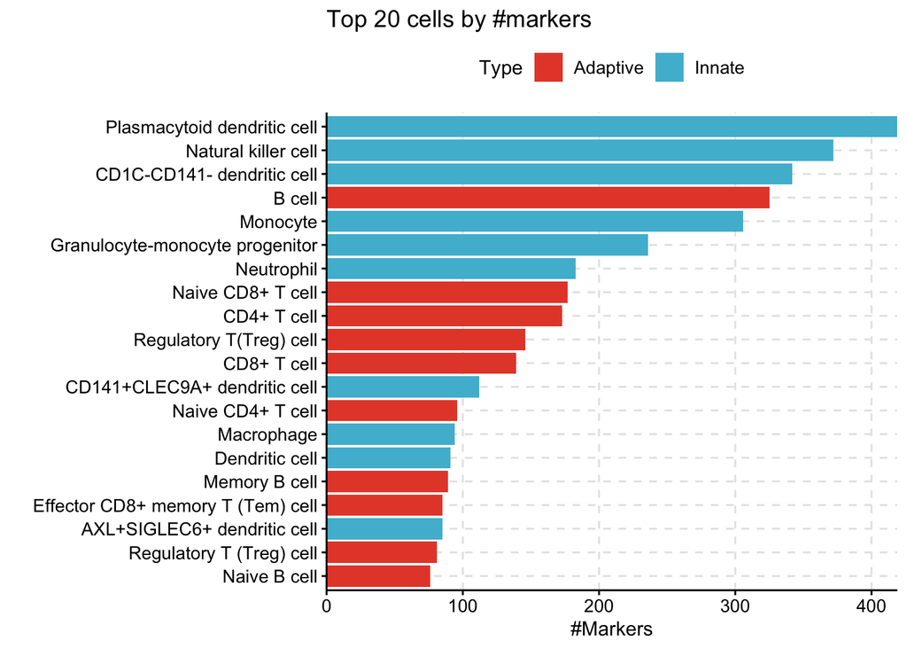

```r
Immune_cells = readRDS(here("Tables", "CellMarker_ImmuneCells.rds"))
Immune_cells_markersbycells = Immune_cells %>%
  group_by(cell_name, Type) %>%
  summarise(n_markers = n()) %>%
  arrange(desc(n_markers))
Immune_cells_markersbycells_top = Immune_cells_markersbycells[1:20, ]

ggImmune_cells_cellsbyimmune = ggplot(Immune_cells_markersbycells_top) +
  aes(x = reorder(cell_name, n_markers), y = n_markers, fill = Type) +
  scale_fill_npg() +
  geom_col() +
  labs(
    x = "",
    y = "#Markers",
    title = "Top 20 cells by #markers"
  ) +
  coord_flip() +
  theme_minimal() +
  theme(axis.text = element_text(color = "black", size = 10),
        legend.text = element_text(color = "black", size = 10),
        axis.line.x  = element_line(size = 0.5, color ="black"),
        axis.line.y  = element_line(size = 0.5, color ="black"),
        axis.text.x = element_text(angle = 0, vjust = 1, hjust=0.5),
        axis.ticks = element_line(size = 0.5, color ="black"),
        panel.grid.major = element_line(linetype = 2, color = "gray90"),
        panel.grid.minor = element_line(linetype = 2, size = 0, color = "gray90"),
        # panel.grid.x = element_line(linetype = 2, color = "gray75"),
        # panel.grid.y = element_line(linetype = 2, color = "gray75"),
        strip.text = element_text(size = 10, color = "black"),
        legend.direction = "horizontal",
        legend.position = "top") +
  scale_y_continuous(expand = c(0, 0))
ggImmune_cells_cellsbyimmune
```

```r
ggImmune_cells_cellsbyimmune %>%
  ggsave(filename = here("Figures", "CellMarker_Top10_cellsbyn_markers.png"), width = 7, height = 5)
```

Number of Cells by immune system

```r
Immune_cells_cellsbyimmune = Immune_cells %>%
  group_by(Type, cell_name) %>%
  summarise(n_cells = n()) %>%
  group_by(Type) %>%
  summarise(n_cells = n())

ggImmune_cells_cellsbyimmune = ggplot(Immune_cells_cellsbyimmune) +
  aes(x = reorder(Type, n_cells), y = n_cells, fill = Type) +
  geom_col() +
  scale_fill_manual(values = c('Innate' = "#989898",
                               'Adaptive' = "#6DF8DF")) +
  labs(
    x = "#Cells",
    y = "Immune system",
    title = "#Cells by immune system"
  ) +
  coord_flip() +
  theme_minimal() +
  geom_text(aes(label = n_cells, y = n_cells),
            position = position_dodge(width = 0.9),
            vjust = -0.2,
            hjust = -0.2,
            size = 3)
ggsave(ggImmune_cells_cellsbyimmune, file= "CellMarker_nCellsbyimmunesystem.png", width = 10, height = 2)

print(ggImmune_cells_cellsbyimmune)
```

### ImmuneGO

```r
organism = "org.Hs.eg.db"
install.packages("GO.db")
BiocManager::install(organism, character.only = TRUE)
library(organism, character.only = TRUE)
library(clusterProfiler)
library(GO.db)

#HGNC symbol to Entrez
x <- org.Hs.egSYMBOL
mapped_genes <- mappedkeys(x)
symbols_entrez <- as.data.frame(x[mapped_genes])

## Entrez to GO
x <- org.Hs.egGO
mapped_genes <- mappedkeys(x)
entrez_geneontology <- as.data.frame(x[mapped_genes])

## GO BP ancestors
go_bp_ancestor = GOBPANCESTOR %>%
  as.data.frame()
colnames(go_bp_ancestor)[1] <- "go_id"
colnames(go_bp_ancestor)[2] <- "go_ancestor"

## GO ID to terms
go_bp = AnnotationDbi::select(GO.db, columns=c("GOID","TERM"), keys= "BP", keytype= "ONTOLOGY") %>%
  clean_names() %>%
  select(go_id = goid, term)

## GO child and ancestor
go_bp_ancestor = go_bp_ancestor %>%
  inner_join(go_bp %>% rename(go_ancestor = go_id), by = "go_ancestor") %>%
  rename(term_ancestor = term)

#GO ids to terms
go_bp = AnnotationDbi::select(GO.db, columns=c("GOID","TERM"), keys="BP", keytype="ONTOLOGY") %>%
  clean_names() %>%
  rename(go_id = goid) %>%
  select(-ontology) %>%
  right_join(entrez_geneontology, by = "go_id") %>%
  right_join(symbols_entrez, by = "gene_id") %>%
  clean_names() %>%
  left_join(go_bp_ancestor, by = "go_id") %>%
  distinct()

#GO immune process

immunego_go.bp = go_bp %>%
  filter(term_ancestor == "immune system process") %>%
  mutate(term = toupper(term))

ImmuneGO_Annotated_Genes_26_2_24 = ImmuneGO_Annotated_GO_8_2_24 %>%
  select(-"...1") %>%
  mutate(genes = str_replace_all(genes, "\\s+", "")) %>%
  separate_rows(genes, sep = ",") %>%
  full_join(immunego_go.bp %>% select(genes = symbol, process = term), by = join_by("process", "genes")) %>%
  distinct()

ImmuneGO_Annotated_GO_26_2_24 = ImmuneGO_Annotated_Genes_26_2_24 %>%
  group_by(process) %>%
  summarize(genes = paste0(genes, collapse = ",")) %>%
  inner_join(ImmuneGO_Annotated_Genes_26_2_24 %>% select(-genes) %>% distinct(), by = "process")

write.csv(ImmuneGO_Annotated_GO_26_2_24, file = "ImmuneGO_Annotated_GO_26_2_24.csv", row.names = F)

write.csv(ImmuneGO_Annotated_Genes_26_2_24, file = "ImmuneGO_Annotated_Genes_26_2_24.csv", row.names = F)
```

Group immune system genes by process and cell

```r
ImmuneGO_Annotated_unique = ImmuneGO_Annotated_Genes %>%
  filter(go_term != "Manual")

#Agrupar genes de todos os processos do sistema imune ----

ImmuneGO_Adaptive <- ImmuneGO_Annotated_unique %>%
  filter(immune_system == "Adaptive") %>%
  summarize(set_size = n(),
            genes = paste(genes, collapse = ",")) %>%
  mutate(process = "ADAPTIVE IMMUNE SYSTEM",
  `Gene set, short` = "Adaptive immune system",
  `Immune system` = "Adaptive",
  `Immune sub-system` = "General",
  `Immune tissue` = "General",
  `GO.TERM` = "Manual") %>%
  clean_names()

ImmuneGO_Innate <- ImmuneGO_Annotated_unique %>%
  filter(immune_system == "Innate") %>%
  summarize(set_size = n(),
            genes = paste(genes, collapse = ",")) %>%
  mutate(process = "INNATE IMMUNE SYSTEM",
  `Gene set, short` = "Innate immune system",
  `Immune system` = "Innate",
  `Immune sub-system` = "General",
  `Immune tissue` = "General",
  `GO.TERM` = "Manual") %>%
  clean_names()

ImmuneGO_Complement <- ImmuneGO_Annotated_unique %>%
  filter(immune_system == "Complement") %>%
  summarize(set_size = n(),
            genes = paste(genes, collapse = ",")) %>%
  mutate(process = "COMPLEMENT",
  `Gene set, short` = "Complement immune system",
  `Immune system` = "Complement",
  `Immune sub-system` = "General",
  `Immune tissue` = "General",
  `GO.TERM` = "Manual") %>%
  clean_names()

ImmuneGO_Inflammation <- ImmuneGO_Annotated_unique %>%
  filter(immune_sub_system == "Inflammation") %>%
  summarize(set_size = n(),
            genes = paste(genes, collapse = ",")) %>%
  mutate(process = "INFLAMMATION",
  `Gene set, short` = "Inflammation",
  `Immune system` = "Innate",
  `Immune sub-system` = "Inflammation",
  `Immune tissue` = "General",
  `GO.TERM` = "Manual") %>%
  clean_names()

ImmuneGO_Interferon <- ImmuneGO_Annotated_unique %>%
  filter(immune_sub_system %in% c("Antiviral", "Interferon")) %>%
  summarize(set_size = n(),
            genes = paste(genes, collapse = ",")) %>%
  mutate(process = "ANTIVIRAL & IFN",
  `Gene set, short` = "Antiviral and Interferon",
  `Immune system` = "Innate",
  `Immune sub-system` = "Antiviral and Interferon",
  `Immune tissue` = "General",
  `GO.TERM` = "Manual") %>%
  clean_names()

ImmuneGO_ARPP = ImmuneGO_Annotated_unique %>%
  filter(immune_sub_system %in% c("PRR", "APC")) %>%
  summarize(set_size = n(),
            genes = paste(genes, collapse = ",")) %>%
  mutate(process = "ARPP",
  `Gene set, short` = "Antigen receptors, processing and presentation",
  `Immune system` = "Innate",
  `Immune sub-system` = "APC",
  `Immune tissue` = "APC",
  `GO.TERM` = "Manual") %>%
  clean_names()


ImmuneGO_Innate_DC <- ImmuneGO_Annotated_unique %>%
  filter(immune_tissue == "Dendritic cell") %>%
  summarize(set_size = n(),
            genes = paste(genes, collapse = ",")) %>%
  mutate(process = "DENDRITIC CELL",
  `Gene set, short` = "Dendritic cell",
  `Immune system` = "Innate",
  `Immune sub-system` = "Cell",
  `Immune tissue` = "APC",
  `GO.TERM` = "Manual") %>%
  clean_names()

ImmuneGO_Innate_Macrophage <- ImmuneGO_Annotated_unique %>%
  filter(immune_tissue == "Macrophage") %>%
  summarize(set_size = n(),
            genes = paste(genes, collapse = ",")) %>%
  mutate(process = "MACROPHAGE",
  `Gene set, short` = "Macrophage",
  `Immune system` = "Innate",
  `Immune sub-system` = "Cell",
  `Immune tissue` = "APC",
  `GO.TERM` = "Manual") %>%
  clean_names()

ImmuneGO_Innate_Mastcell <- ImmuneGO_Annotated_unique %>%
  filter(immune_tissue == "Mast cell") %>%
  summarize(set_size = n(),
            genes = paste(genes, collapse = ",")) %>%
  mutate(process = "MAST CELL",
  `Gene set, short` = "Mast cell",
  `Immune system` = "Innate",
  `Immune sub-system` = "Cell",
  `Immune tissue` = "Mast cell",
  `GO.TERM` = "Manual") %>%
  clean_names()

ImmuneGO_Innate_Neutrophil <- ImmuneGO_Annotated_unique %>%
  filter(immune_tissue == "Neutrophil") %>%
  summarize(set_size = n(),
            genes = paste(genes, collapse = ",")) %>%
  mutate(process = "NEUTROPHIL",
  `Gene set, short` = "Neutrophil",
  `Immune system` = "Innate",
  `Immune sub-system` = "Cell",
  `Immune tissue` = "Neutrophil",
  `GO.TERM` = "Manual") %>%
  clean_names()

ImmuneGO_Innate_Eosinophil <- ImmuneGO_Annotated_unique %>%
  filter(immune_tissue == "Eosinophil") %>%
  summarize(set_size = n(),
            genes = paste(genes, collapse = ",")) %>%
  mutate(process = "EOSINOPHIL",
  `Gene set, short` = "Eosinophil",
  `Immune system` = "Innate",
  `Immune sub-system` = "Cell",
  `Immune tissue` = "Eosinophil",
  `GO.TERM` = "Manual") %>%
  clean_names()

ImmuneGO_Innate_NK <- ImmuneGO_Annotated_unique %>%
  filter(immune_tissue == "NK cell") %>%
  summarize(set_size = n(),
            genes = paste(genes, collapse = ",")) %>%
  mutate(process = "NK CELL",
  `Gene set, short` = "Natural Killer Cell",
  `Immune system` = "Innate",
  `Immune sub-system` = "Cell",
  `Immune tissue` = "NK cell",
  `GO.TERM` = "Manual") %>%
  clean_names()

ImmuneGO_Innate_Monocyte <- ImmuneGO_Annotated_unique %>%
  filter(immune_tissue == "Monocyte") %>%
  summarize(set_size = n(),
            genes = paste(genes, collapse = ",")) %>%
  mutate(process = "MONOCYTE",
  `Gene set, short` = "Monocyte",
  `Immune system` = "Innate",
  `Immune sub-system` = "Cell",
  `Immune tissue` = "APC",
  `GO.TERM` = "Manual") %>%
  clean_names()

ImmuneGO_Adap_Cellular <- ImmuneGO_Annotated_unique %>%
  filter(immune_sub_system == "Cellular") %>%
  summarize(set_size = n(),
            genes = paste(genes, collapse = ",")) %>%
  mutate(process = "CELLULAR ADAPTIVE IMMUNE SYSTEM",
  `Gene set, short` = "Cellular adaptive immune system",
  `Immune system` = "Adaptive",
  `Immune sub-system` = "Cellular",
  `Immune tissue` = "Cellular",
  `GO.TERM` = "Manual") %>%
  clean_names()


ImmuneGO_Adap_Tcell <- ImmuneGO_Annotated_unique %>%
  filter(immune_tissue == "T cell") %>%
  summarize(set_size = n(),
            genes = paste(genes, collapse = ",")) %>%
  mutate(process = "T CELL",
  `Gene set, short` = "T cell",
  `Immune system` = "Adaptive",
  `Immune sub-system` = "Cellular",
  `Immune tissue` = "Cellular",
  `GO.TERM` = "Manual") %>%
  clean_names()

ImmuneGO_Adap_Thelper <- ImmuneGO_Annotated_unique %>%
  filter(immune_tissue == "T helper") %>%
  summarize(set_size = n(),
            genes = paste(genes, collapse = ",")) %>%
  mutate(process = "T HELPER CELLS",
  `Gene set, short` = "T helper cell",
  `Immune system` = "Adaptive",
  `Immune sub-system` = "Cellular",
  `Immune tissue` = "Cellular",
  `GO.TERM` = "Manual") %>%
  clean_names()

ImmuneGO_Adap_Humoral <- ImmuneGO_Annotated_unique %>%
  filter(immune_sub_system == "Humoral") %>%
  summarize(set_size = n(),
            genes = paste(genes, collapse = ",")) %>%
  mutate(process = "HUMORAL ADAPTIVE IMMUNE SYSTEM",
  `Gene set, short` = "Humoral adaptive immune system",
  `Immune system` = "Adaptive",
  `Immune sub-system` = "Humoral",
  `Immune tissue` = "Humoral",
  `GO.TERM` = "Manual") %>%
  clean_names()

ImmuneGO_Adap_Bcell <- ImmuneGO_Annotated_unique %>%
  filter(immune_tissue == "B cell") %>%
  summarize(set_size = n(),
            genes = paste(genes, collapse = ",")) %>%
  mutate(process = "B CELL",
  `Gene set, short` = "B cell",
  `Immune system` = "Adaptive",
  `Immune sub-system` = "Humoral",
  `Immune tissue` = "B cell",
  `GO.TERM` = "Manual") %>%
  clean_names()

ImmuneGO_Adap_Ig <- ImmuneGO_Annotated_unique %>%
  filter(immune_tissue == "B cell") %>%
  summarize(set_size = n(),
            genes = paste(genes, collapse = ",")) %>%
  mutate(process = "IMMUNOGLOBULIN MEDIATED RESPONSE",
  `Gene set, short` = "Ig-mediated response",
  `Immune system` = "Adaptive",
  `Immune sub-system` = "Humoral",
  `Immune tissue` = "B cell",
  `GO.TERM` = "Manual") %>%
  clean_names()

ImmuneGO_other <- ImmuneGO_Annotated_unique %>%
  filter(immune_system == "General" |
         immune_tissue == "Leukocyte") %>%
  summarize(set_size = n(),
            genes = paste(genes, collapse = ",")) %>%
  mutate(process = "GENERAL",
  `Gene set, short` = "General",
  `Immune system` = "General",
  `Immune sub-system` = "General",
  `Immune tissue` = "General",
  `GO.TERM` = "Manual") %>%
  clean_names()


ImmuneGO_antimicrobial <- ImmuneGO_Annotated_unique %>%
  filter(immune_tissue == "Antimicrobial") %>%
  summarize(set_size = n(),
            genes = paste(genes, collapse = ",")) %>%
  mutate(process = "ANTIMICROBIAL",
  `Gene set, short` = "Antimicrobial immune response",
  `Immune system` = "General",
  `Immune sub-system` = "General",
  `Immune tissue` = "General",
  `GO.TERM` = "Manual") %>%
  clean_names()


# Unite sets -----

ImmuneGO_Annotated_GO = bind_rows(ImmuneGO_Adaptive,
                            ImmuneGO_Innate,
                            ImmuneGO_Complement,
                            ImmuneGO_Inflammation,
                            ImmuneGO_Interferon,
                            ImmuneGO_ARPP,
                            ImmuneGO_Innate_Macrophage,
                            ImmuneGO_Innate_Mastcell,
                            ImmuneGO_Innate_Neutrophil,
                            ImmuneGO_Innate_Eosinophil,
                            ImmuneGO_Innate_NK,
                            ImmuneGO_Innate_Monocyte,
                            ImmuneGO_Adap_Cellular,
                            ImmuneGO_Adap_Tcell,
                            ImmuneGO_Adap_Thelper,
                            ImmuneGO_Adap_Humoral,
                            ImmuneGO_Adap_Bcell,
                            ImmuneGO_Adap_Ig,
                            ImmuneGO_other,
                            ImmuneGO_antimicrobial,
                            ImmuneGO_Innate_DC,
                            ImmuneGO_Annotated_unique) %>%
  select(process:go_term, set_size:genes) %>%
  distinct()

ImmuneGO_Annotated_Genes = ImmuneGO_Annotated_GO %>%
   separate_rows(genes, sep = ",")

# Separate TCR and BCR repertoire genes
TCR_BCR_repertoire = ImmuneGO_Annotated_Genes %>%
  filter(grepl("^TR", genes) & process == "ADAPTIVE IMMUNE SYSTEM" |
           grepl("^IG", genes) & process == "ADAPTIVE IMMUNE SYSTEM" |
           grepl("^TR", genes) & process == "CELLULAR ADAPTIVE IMMUNE SYSTEM" |
         grepl("^IG", genes) & process == "HUMORAL ADAPTIVE IMMUNE SYSTEM") %>%
  mutate(process = if_else(process == "CELLULAR ADAPTIVE IMMUNE SYSTEM", "TCR REPERTOIRE",
                           "BCR REPERTOIRE"),
         gene_set_short = if_else(process == "TCR REPERTOIRE",
                                  "TCR REPERTOIRE",
                           "BCR REPERTOIRE"),
         process = if_else(grepl("^TR", genes), "TCR REPERTOIRE", "BCR REPERTOIRE"),
         immune_sub_system = if_else(process == "TCR REPERTOIRE", "Cellular", "Humoral"),
         immune_tissue = if_else(process == "TCR REPERTOIRE", "Cellular", "Humoral"))

immunego_manual = ImmuneGO_Annotated_Genes %>%
  filter(go_term == "Manual") %>%
  anti_join(TCR_BCR_repertoire %>% select(genes) %>% distinct(), by = "genes") %>%
  bind_rows()

#Verify if all genes are annotated. If there are no left genes, you are good to go
a = ImmuneGO_Annotated_Genes %>% filter(go_term == "Manual") %>% select(genes) %>% distinct()
ImmuneGO_Annotated_Genes %>% select(process, genes, immune_system) %>% anti_join(a, by = "genes")


#Salvar
write.csv(ImmuneGO_Annotated_GO, file = paste0("ImmuneGO_Annotated_GO_", today(), ".csv"), row.names = F)
saveRDS(ImmuneGO_Annotated_GO, file = paste0("ImmuneGO_Annotated_GO_", today(), ".rds"))
saveRDS(ImmuneGO_Annotated_Genes, file = paste0("ImmuneGO_Annotated_Genes_", today(), ".rds"))

#Display
view(ImmuneGO_Annotated_GO)
view(ImmuneGO_Annotated_Genes)
```

```r
#Top 10 gene sets
ImmuneGO_Annotated_unique_top10 = ImmuneGO_Annotated_GO %>%
  clean_names() %>%
  arrange(desc(set_size)) %>%
  slice_head(n = 20) %>%
  mutate(immune_system = if_else(gene_set_short == "Adaptive Immune response", "Adaptive", immune_system))

#Gráfico de barras
ImmuneGO_top10_barplot = ggplot(ImmuneGO_Annotated_unique_top10) +
 aes(x = reorder(gene_set_short, set_size),
     weight = set_size,
     fill = immune_system) +  # Use reorder para reordenar as barras +
  geom_bar()+
  scale_fill_manual(
    values = c(Adaptive = "#6DF8DF",
    Complement = "#e9edc9",
    General = "#bde0fe",
    Innate = "#989898",
    Undefined = "#edede9")) +
 labs(y = "Set size", title = "ImmuneGO", subtitle = "Top 10 GO, by set size") +
 coord_flip() +
 theme_minimal()

#Salvar
ggsave(ImmuneGO_top10_barplot, file="ImmuneGO_top10_barplot.png", width = 10, height = 6)

#Display
head(ImmuneGO_top10_barplot)
```

### ImmuneGO + BTM

```r
btm_annotation_genes = readRDS(here("VaxGO gene sets", "btm_annotation_genes.rds"))
ImmuneGO_Annotated_Genes = readRDS(here("VaxGO gene sets", "ImmuneGO_Annotated_Genes_2024-03-26.rds"))
ImmuneGO_Annotated_GO = read_csv(here("VaxGO gene sets", "ImmuneGO_Annotated_GO_2024_03_26.csv"))

#Unite genes
immunego_btm_genes = ImmuneGO_Annotated_Genes %>%
              select(genes) %>%
              distinct() %>%
              mutate(set = "ImmuneGO") %>%
  bind_rows(btm_annotation_genes %>%
              select(genes) %>%
              distinct() %>%
              mutate(set = "BTM")) %>%
  arrange(genes)

immunego_btm_genes_joined = immunego_btm_genes %>%
  bind_rows(immunego_btm_genes %>% mutate(set = "BTM and ImmuneGO")) %>%
  distinct()


#Unite subsets
btm_annotation_grouped = btm_annotation_genes %>%
  group_by(complete_name) %>%
  rename(process = complete_name) %>%
  mutate(genes = paste0(genes, collapse = ",")) %>%
  distinct() %>%
  mutate(genes = paste0(genes, collapse = ","),
            immune_set = "BTM by Modules") %>%
    select(process,
           immune_system:cells,
           set_size = module_size,
           genes,
           immune_set)

ImmuneGO_annotation_modules = ImmuneGO_Annotated_GO %>%
  filter(go_term != "Manual") %>%
    select(process = gene_set_short,
           immune_system:immune_tissue,
           set_size, genes) %>%
    rename(cells = immune_tissue,
           immune_subsystem = immune_sub_system) %>%
    mutate(immune_set = "ImmuneGO by Modules")

immunego_btm_specific_grouped = btm_annotation_grouped %>%
  bind_rows(ImmuneGO_annotation_modules)

immunego_btm_specific_grouped %>%
  write_csv(file = here("VaxGO gene sets", "ImmuneGO_BTM_grouped_genesets_specific.csv"))


#By immune system
btm_immunesystem = btm_annotation_genes %>%
  select(immune_system, genes) %>%
  distinct() %>%
  rename(process = immune_system) %>%
  group_by(process) %>%
  summarize(genes = paste0(genes, collapse = ","),
            set_size = n(),
            process = str_to_upper(process),
            # id = process,
            immune_system = process,
            immune_subsystem = process,
            cells = process,
            complete_name = process,
            annotation_level = "Manual",
            immune_set = "BTM by Immune System") %>%
  distinct()

#By immune subsystem
btm_immunesubsystem = btm_annotation_genes %>%
  select(immune_subsystem, genes) %>%
  distinct() %>%
  rename(process = immune_subsystem) %>%
  group_by(process) %>%
  summarize(genes = paste0(genes, collapse = ","),
            process = str_to_upper(process),
            set_size = n(),
            # id = process,
            immune_system = process,
            immune_subsystem = process,
            cells = process,
            complete_name = process,
            annotation_level = "Manual",
            immune_set = "BTM by Immune Sub-System") %>%
  distinct()
#By cell
btm_cells = btm_annotation_genes %>%
  select(cells, genes) %>%
  distinct() %>%
  rename(process = cells) %>%
  group_by(process) %>%
  summarize(genes = paste0(genes, collapse = ","),
            set_size = n(),
            process = str_to_upper(process),
            # id = process,
            immune_system = process,
            immune_subsystem = process,
            cells = process,
            annotation_level = "Manual",
            complete_name = process,
            immune_set = "BTM by Immune Cell") %>%
  distinct()
#Merge
btm_manual = bind_rows(btm_immunesystem,
          btm_immunesubsystem,
          btm_cells) %>%
  arrange(complete_name) %>%
  select(complete_name, everything()) %>%
  distinct()

btm_manual_grouped = bind_rows(btm_manual,
                               btm_annotation_grouped) %>%
  distinct()


#Merge ImmuneGO and BTM main processes
immunego_btm_manual_grouped = btm_manual %>%
  select(process, genes, immune_set, set_size) %>%
  mutate(immune_set = "BTM") %>%
  bind_rows(ImmuneGO_Annotated_GO %>%
              filter(go_term == "Manual") %>%
              select(process, genes, set_size) %>%
              mutate(immune_set = "ImmuneGO")) %>%
  arrange(process) %>%
  mutate(process = case_when(process == "ADAPTIVE" ~ "ADAPTIVE IMMUNE SYSTEM",
                              process == "ALL" ~ "IMMUNE SYSTEM",
                              process == "GENERAL" ~ "LEUKOCYTES",
                              process == "CELLS" ~ "LEUKOCYTES",
                              process == "DCS" ~ "DENDRITIC CELL",
                              process == "APP" ~ "ARPP",
                              process == "CELLULAR" ~ "CELLULAR ADAPTIVE IMMUNE SYSTEM",
                              process == "DCS, MYELOID" ~ "DENDRITIC CELL",
                              process == "GENERIC" ~ "LEUKOCYTES",
                              process == "HUMORAL" ~ "HUMORAL ADAPTIVE IMMUNE SYSTEM",
                              process == "INNATE" ~ "INNATE IMMUNE SYSTEM",
                              process == "INTERFERON" ~ "ANTIVIRAL & IFN",
                              process == "NK" ~ "NK CELL",
                              process == "B CELL, PLASMA CELL" ~ "B CELL",
                              process == "PLASMA CELL" ~ "B CELL",
                              process == "PRR" ~ "ARPP",
                              process == "SIGNALING" ~ "SIGNALING",
                              process == "TH2" ~ "T CELL",
                              process == "TH1" ~ "T CELL",
                              process == "T HELPER CELLS" ~ "T CELL",
                              TRUE ~ process
                              )) %>%
  distinct() %>%
  bind_rows(
    immunego_btm_specific_grouped)

immunego_btm_manual_grouped_genes = immunego_btm_manual_grouped %>%
  separate_rows(genes, sep = ",") %>%
  distinct()

immunego_btm_manual_grouped_genes = immunego_btm_manual_grouped_genes %>%
  bind_rows(
    immunego_btm_manual_grouped_genes %>%
      mutate(immune_set = "BTM and ImmuneGO") %>%
      distinct()
  )


immunego_btm_manual_grouped %>%
  write_csv(file = here("VaxGO gene sets", "ImmuneGO_BTM_grouped_genesets.csv"))

immunego_btm_manual_grouped_genes %>%
  write_csv(file = here("VaxGO gene sets", "ImmuneGO_BTM_grouped_genes.csv"))
```

Plot relative frequency of genes by main process

```r
#Get exclusive genes
immunego_only_genes = immunego_btm_manual_grouped_genes %>%
  filter(immune_set == "ImmuneGO") %>%
  select(-immune_set, -set_size) %>%
  anti_join(immunego_btm_manual_grouped_genes %>%
            filter(immune_set == "BTM"),
            by = "genes") %>%
  mutate(immune_set = "ImmuneGO only") %>%
  distinct()

btm_only_genes = immunego_btm_manual_grouped_genes %>%
  filter(immune_set == "BTM") %>%
  select(-immune_set, -set_size) %>%
  anti_join(immunego_btm_manual_grouped_genes %>%
            filter(immune_set == "ImmuneGO"),
            by = "genes") %>%
  mutate(immune_set = "BTM only") %>%
  distinct()

btm_immune_joined_stats = immunego_only_genes %>%
  bind_rows(btm_only_genes) %>%
  distinct() %>%
  mutate(immune_set = "BTM and ImmuneGO") %>%
  select(process, genes, immune_set) %>%
  distinct() %>%
  group_by(process) %>%
  distinct() %>%
  mutate(ntotal=n()) %>%
  ungroup() %>%
  select(process, ntotal) %>%
  distinct() %>%
  inner_join(immunego_only_genes %>%
               bind_rows(btm_only_genes), by = "process") %>%
  group_by(process, immune_set) %>%
  mutate(n = n(),
         genes = paste0(genes, collapse = ",")) %>%
  select(-genes) %>%
  distinct() %>%
  ungroup() %>%
  mutate(n_perc = (n/ntotal) * 100)

btm_immune_joined_stats_plot = btm_immune_joined_stats %>%
  filter(!process %in% c("LYMPHOCYTE",
                         "IMMUNOGLOBULIN MEDIATED RESPONSE",
                         "MYELOID CELL",
                         "SIGNALING",
                         "IMMUNE SYSTEM")) %>%
  mutate(process = str_to_title(process),
         process = fct_relevel(process,
                               "Leukocytes",
                               "Adaptive Immune System",
                               "Innate Immune System",
                               "Complement" ,
                               "Cellular Adaptive Immune System",
                               "Humoral Adaptive Immune System",
                               )) %>%
 ggplot() +
  aes(x = n_perc, y = fct_rev(process), fill = immune_set) +
  geom_bar(stat = "summary", fun = "sum", position = "fill") +
  scale_fill_manual(values = c("BTM only" = "#5e60ce",
                               "ImmuneGO only" = "#00A087FF")) +
  theme_minimal() +
  theme(legend.position = "right",
        strip.text.x = element_text(color = "black", size = 12),
        axis.text.x = element_text(color = "black", size = 10),
        axis.text.y = element_text(vjust = 0.5, size = 10, color = "black"),
        axis.line = element_line(size = 0.5, colour = "black", linetype=1),
        axis.ticks = element_line(size = 0.5, color = "black")) +
  labs(x = "%Coverage",
       y = "",
       fill = "Immune set",
       subtitle = "Merged data",
       title = "ImmuneGO and BTM main processes genes") +
  scale_x_continuous(expand = c(0,0)) +
  geom_text(aes(label = paste0(round(n_perc, 0))),
            position = position_fill(vjust = 0.5),
            size = 3,
            color = "white",
            fontface = "bold")

btm_immune_joined_stats_plot %>%
  ggsave(filename = here("Figures", "ImmuneGO_BTM_Joined_Stats_barplot.png"),
         width = 10,
         height = 7)

btm_immune_joined_stats_plot
```

### VAX MSigDB

```r
#Importar arquivo
VaxSigDB_genesets = VAX_GeneSets_Annotated_26_10_23

# Divida os dados em blocos de informações para cada vacina
vaccines_att <- split(VaxSigDB_genesets$Col2, VaxSigDB_genesets$Col1)

# Combine data
VAX_Genesets <- bind_rows(lapply(vaccines_att, function(x) data.frame(t(x))), .id = "V")

# Name a new index column
colnames(VAX_Genesets) <- paste0("V", seq_len(ncol(VAX_Genesets)))

# Transpose
rownames(VAX_Genesets) <- VAX_Genesets$V1
VAX_Genesets = VAX_Genesets %>%
  t() %>%
  as.data.frame()

#Order columns
VAX_Genesets = VAX_Genesets %>%
  select(STANDARD_NAME, everything()) %>%
  filter(STANDARD_NAME != "STANDARD_NAME")
rownames(VAX_Genesets) = VAX_Genesets$SYSTEMATIC_NAME
VAX_Genesets = VAX_Genesets %>% select(STANDARD_NAME,
                                       DESCRIPTION_BRIEF,
                                       DESCRIPTION_FULL,
                                       PMID,
                                       AUTHORS,
                                       SYSTEMATIC_NAME,
                                       GENE_SYMBOLS,
                                       everything())

#Anotar novas colunas
VAX_Genesets <- VAX_Genesets %>%
  mutate(
    SAMPLE_SOURCE = ifelse(
      grepl("pbmc|peripheral blood mononuclear cell|peripheral blood mononuclear cells", DESCRIPTION_FULL, ignore.case = TRUE) |
      grepl("pbmc|peripheral blood mononuclear cell|peripheral blood mononuclear cells", DESCRIPTION_BRIEF, ignore.case = TRUE),
      "PBMC",
      ifelse(
        grepl("whole blood", DESCRIPTION_FULL, ignore.case = TRUE) |
        grepl("whole blood", DESCRIPTION_BRIEF, ignore.case = TRUE) |
        grepl("_BLOOD", STANDARD_NAME, ignore.case = TRUE)  ,
        "WHOLE BLOOD",
        "OTHER")),
    REGULATION = ifelse(
      grepl("up", DESCRIPTION_BRIEF, ignore.case = TRUE),
      "UP",
      ifelse(
        grepl("down", DESCRIPTION_BRIEF, ignore.case = TRUE),
        "DOWN",
        "UNKNOWN")))

#Reordenar colunas
VAX_Genesets = VAX_Genesets %>% select(SAMPLE_SOURCE, REGULATION, everything())

# Salvar
write.csv(VAX_Genesets, file = "VAXSigDB_Annotated.csv") #Continuar a anotação no Google Sheets

head(VAX_Genesets)
```

Long table with Gene symbols

```r
############## Long table with Gene symbols

VAX_Genesets = VAXSigDB_Annotated

VAX_Genes <- VAX_Genesets %>%
  mutate(GENE = GENE_SYMBOLS) %>%
  separate_rows(GENE, sep = ",") %>%
  select(GENE, everything()) %>%
  group_by(STANDARD_NAME) %>%
  mutate(SetSize = n()) %>%
  relocate(SetSize, .after = GENE_SYMBOLS)

VAX_GeneSets_annotated <- VAX_Genes %>%
  select(-GENE) %>%
  distinct()

#Salvar
write.csv(VAX_Genes, file = "VAX_Genes_Annotated_RAW.csv")
write.csv(VAX_GeneSets_annotated, file = "VAX_Genesets_Annotated_RAW.csv")

#Display
head(VAX_GeneSets_annotated)
```

Filtering

```r
unique(VAX_GeneSets_annotated$STUDY_TYPE)
#"CORRELATION"
#"VACCINE"
#"SUBSET"
#"CHALLENGE"

unique(VAX_GeneSets_annotated$STUDY_SUBTYPE)
# "ANTIBODY"
# "VAC ONLY"
# "BOOSTER"
# "VAC VS CTRL"
# "SIGNATURE"
# "ADVERSE EVENT"
# "COMPARISON"
# "RESPONDER VS NON RESPONDER"
# "AGE"
# "RESPONDER"
# "ADJUVANT"
# "NON RESPONDER"
# "ANTIMICROBIAL ACTIVITY"
# "CELLS"
# "CHALLENGE"
# "TOP DEGS"
# "PROTECTION"
# "TRAINING SET"
# "EXON ANALYSIS"
# "DOSE"
# "VAC VS OTHER"


# Subset de vacinas para as seguintes análises comparativas
VAX_GeneSets_Blood_PBMC_VAC = VAX_GeneSets_annotated %>%
  filter(SAMPLE_SOURCE %in% c("PBMC", "WHOLE BLOOD"),
         STUDY_TYPE %in% c("VACCINE"))

# Subset de vacinas com resultados de comparações entre vacinas, adjuvantes, idade e sexo
VAX_GeneSets_Blood_PBMC_CORR = VAX_GeneSets_annotated %>%
  filter(SAMPLE_SOURCE %in% c("PBMC", "WHOLE BLOOD"),
         STUDY_TYPE %in% c("CORRELATION"))

# Subset com resultados de correlações com resposta inata, celular e humoral
VAX_GeneSets_Blood_PBMC_SUBSETS = VAX_GeneSets_annotated %>%
  filter(SAMPLE_SOURCE %in% c("PBMC", "WHOLE BLOOD"),
         STUDY_TYPE %in% c("SUBSET"))


# Subset de vacinas com genes associados a eventos adversos
VAX_GeneSets_Blood_PBMC_CHALLENGE = VAX_GeneSets_annotated %>%
  filter(SAMPLE_SOURCE %in% c("PBMC", "WHOLE BLOOD"),
         STUDY_TYPE %in% c("CHALLENGE"))

VAX_GeneSets_Blood_PBMC_VAC.stats = VAX_GeneSets_Blood_PBMC_VAC %>%
  group_by(VACCINE, PLATFORM, REGULATION, `TARGET_PATHOGEN_DISEASE`, MICROBE_TYPE) %>%
  summarise(Count = n()) %>%
  arrange(desc(Count))
```

# Analysis

## Descriptive

| immune_set | immune_system | immune_subsystem | cells | n_processes | immune_process_group |
| --- | --- | --- | --- | --- | --- |
| BTM by Modules | Adaptive | Cellular | T cell | 19 | Adaptive, Cellular, T cell |
| BTM by Modules | Adaptive | Cellular | Th1 | 1 | Adaptive, Cellular, Th1 |
| BTM by Modules | Adaptive | Cellular | Th2 | 2 | Adaptive, Cellular, Th2 |
| BTM by Modules | Adaptive | General | Lymphocyte | 3 | Adaptive, General, Lymphocyte |
| BTM by Modules | Adaptive | Humoral | B cell | 14 | Adaptive, Humoral, B cell |
| BTM by Modules | Adaptive | Humoral | B cell, Plasma cell | 1 | Adaptive, Humoral, B cell, Plasma cell |
| BTM by Modules | Adaptive | Humoral | Plasma cell | 2 | Adaptive, Humoral, Plasma cell |
| BTM by Modules | Complement | Complement | Complement | 2 | Complement, Complement, Complement |
| BTM by Modules | General | General | Generic | 1 | General, General, Generic |
| BTM by Modules | General | Signaling | Generic | 4 | General, Signaling, Generic |

[output cut: 72 more lines]

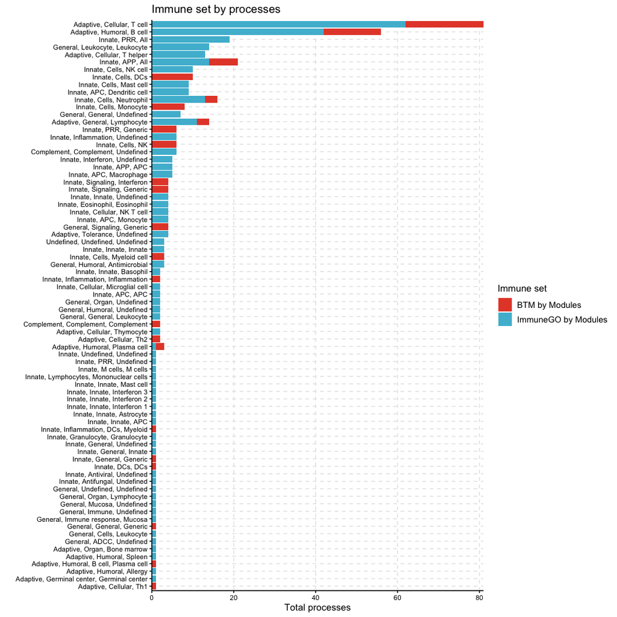

Exclusive genes by set

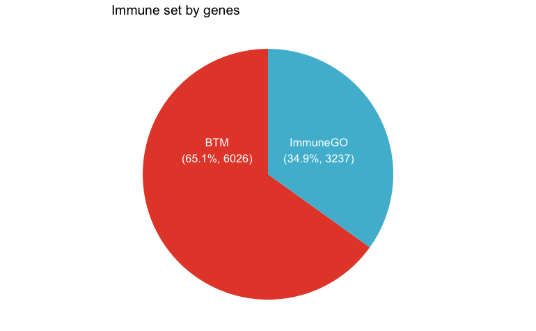

```r
immunego_genes_total %>%
  summarize(immune_set,
            n_genes,
            n_genes_perc = n_genes/sum(n_genes)*100,
            n_genes_perc = n_genes_perc %>% round(1)) %>%
  mutate(label = paste0(immune_set, "\n", "(", n_genes_perc, "%, ", n_genes, ")")) %>%
  pivot_longer(cols = -c(immune_set, label),
               names_to = "var",
               values_to = "value") %>%
 filter(var %in% "n_genes_perc") %>%
 ggplot() +
  aes(x = var, y = value, fill = immune_set) +
  geom_col(show.legend = F) +
  geom_text(aes(label = label),
            vjust = -2,
            color = "white") +
  scale_fill_npg() +
  coord_polar(theta = "y") +

  labs(title = "Immune set by genes") +
  theme_void()
```

Exclusive genes by set in immune processes

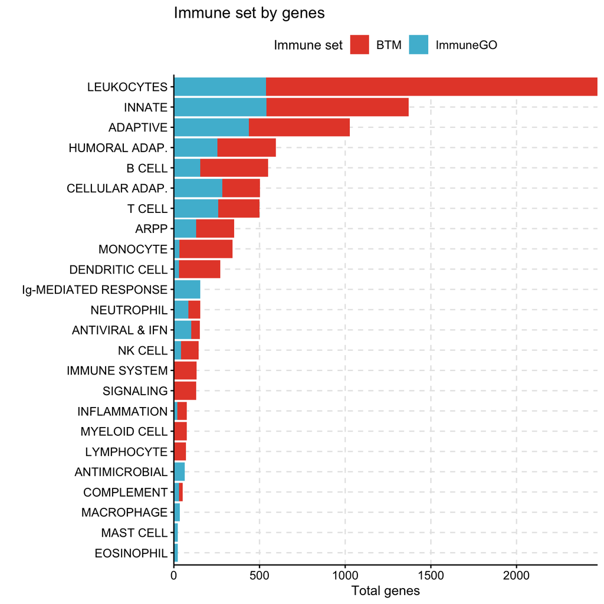

Most shared genes

```r
library(dplyr)
ImmuneGO_BTM_genes %>%
  select(-immune_set) %>%
  distinct() %>%
  filter(is.na(immune_system)) %>%
  group_by(genes) %>%
  summarize(genes,
            n_shared = n()) %>%
  distinct() %>%
  arrange(-n_shared)
```

| genes | n_shared |
| --- | --- |
| TLR4 | 24 |
| BTK | 23 |
| CCL5 | 21 |
| CCL4 | 20 |
| SYK | 20 |
| XCL1 | 20 |
| CCL20 | 19 |
| BCL6 | 17 |
| CCR7 | 17 |
| FCER1G | 17 |

[output cut: 990 more lines]

```r
NA
```

Cell marker

Most genes by cells

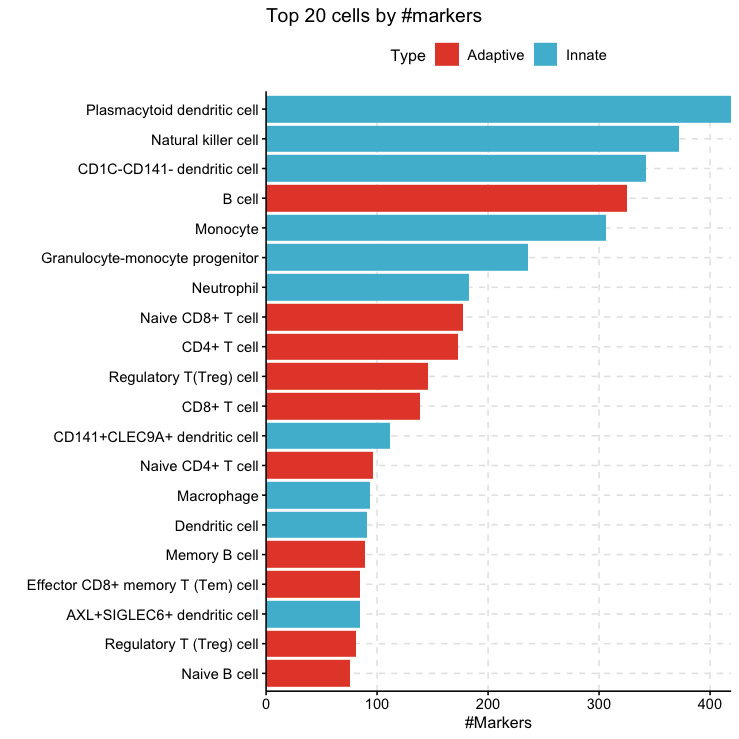

| marker | Type | n_cells |
| --- | --- | --- |
| CD14 | Innate | 140 |
| CD4 | Adaptive | 139 |
| CD19 | Adaptive | 138 |
| CD27 | Adaptive | 108 |
| CD16 | Innate | 101 |
| CD3 | Adaptive | 92 |
| CD56 | Innate | 80 |
| CD38 | Adaptive | 65 |
| CCR7 | Adaptive | 61 |
| HLA-DR | Innate | 54 |

[output cut: 990 more lines]

| marker | n_cells | cells |
| --- | --- | --- |
| CD4 | 150 | CD4+ T cell, CD4+ T helper cell, CD4+CD25+ regulatory T cell, Activated CD4+ T cell, CD4+ T cell, CD4+ T cell, Naive CD4+ T cell, CD4+ T cell, Activated CD4+ T cell, CD4+ T cell, CD4+ T cell, CD4+ T c… |
| CD19 | 148 | B cell, Plasma cell, Plasma cell, B cell, Atypical memory B cell, B cell, Switched memory B cell, Double-negative memory B cell, Transitional B cell, Plasma cell, Naive B cell, Non-switched memory B c… |
| CD14 | 143 | B cell, B cell, Activated CD4+ T cell, Neutrophil, Neutrophil, Neutrophil, Neutrophil, Monocyte, Monocyte, Monocyte, CD14++CD16- monocyte, CD14+CD16+ monocyte, Monocyte, Monocyte, Monocyte, Classical … |
| CD3 | 122 | B cell, B cell, CD4+ T cell, CD4+ T helper cell, CD4+CD25+ regulatory T cell, CD4+ T cell, Naive CD4+ T cell, Effector memory CD4+ T cell, Effector CD4+ T cell, Central memory CD4+ T cell, Central mem… |
| CD27 | 112 | Plasma cell, Memory B cell, Memory B cell, Memory B cell, Atypical memory B cell, B cell, Non-switched memory B cell, Naive B cell, Plasma cell, Transitional B cell, Switched memory B cell, Double-neg… |
| CD16 | 101 | Neutrophil, Neutrophil, Neutrophil, Neutrophil, Neutrophil, Neutrophil, Immature neutrophil, Mature neutrophil, Immature neutrophil, Mature neutrophil, Neutrophil, Neutrophil, Neutrophil, Neutrophil, … |
| CD56 | 83 | Abnormal plasma cell, B cell, CD8+ T cell, Neutrophil, Monocyte, Monocyte, Monocyte, Monocyte lineage, Natural killer T (NKT) cell, Natural killer cell, Natural killer cell, Cytokine induced killer ce… |
| CD38 | 74 | Plasma cell, Plasma cell, Abnormal plasma cell, Plasma cell, Naive B cell, Plasma cell, Transitional B cell, B cell, Naive B cell, Immature transitional B cell, B cell, B cell, Plasmablast, Transition… |
| CCR7 | 65 | B cell, B cell, Naive CD4+ T cell, Effector CD4+ memory T (Tem) cell, Memory CD4+ T cell, Central memory CD4+ T cell, Naive CD4+ T cell, Naive CD4+ T cell, Central memory CD4+ T cell, Central memory C… |
| HLA-DR | 59 | B cell, CD8+ T cell, CD8+ T cell, Regulatory T(Treg) cell, Activated peripheral helper T cell, Neutrophil, Neutrophil, Neutrophil, Monocyte, Intermediate monocyte, Suppressive monocyte, Non-classical … |

[output cut: 990 more lines]

```r
markers_immunesystem = Immune_cells_mainpro %>%
  filter(marker %in% c(markers_cells$data$marker %>% as.character())) %>%
  mutate(marker = fct_relevel(marker, markers_cells$data$marker %>% levels())) %>%
  slice_head(n = 20) %>%
  esquisser()
```

```
Listening on http://127.0.0.1:6636
```

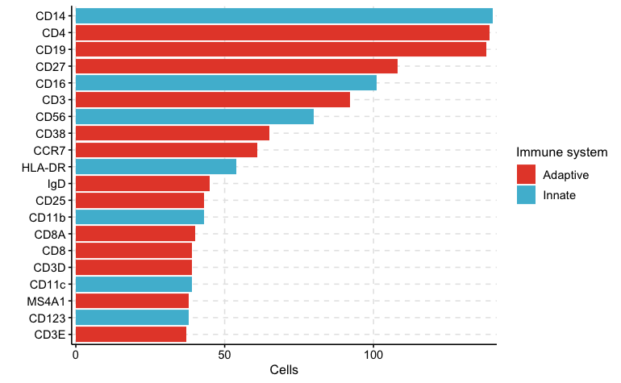

MSigDB Vax

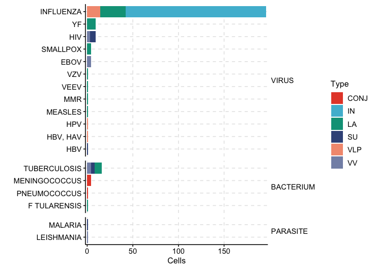

```r
VaxSigDB_Gene_sets_Annotated_RAW %>%
  select(vaccine, platform, target_pathogen_disease, microbe_type) %>%
  distinct() %>%
  group_by(target_pathogen_disease) %>%
  summarize(n_vaccines = n(),
            platform,
            microbe_type) %>%

  ggplot() +
  aes(y = target_pathogen_disease %>%
        fct_reorder(n_vaccines),
      x = n_vaccines,
      fill = platform ) +
  geom_col() +
  scale_fill_npg() +
  theme_minimal() +
  theme(axis.text = element_text(color = "black", size = 10),
        legend.text = element_text(color = "black", size = 10),
        axis.line.x  = element_line(size = 0.5, color ="black"),
        axis.line.y  = element_line(size = 0.5, color ="black"),
        axis.text.x = element_text(angle = 0, vjust = 1, hjust=0.5),
        axis.ticks = element_line(size = 0.5, color ="black"),
        panel.grid.major = element_line(linetype = 2, color = "gray90"),
        panel.grid.minor = element_line(linetype = 2, size = 0, color = "gray90"),
        # panel.grid.x = element_line(linetype = 2, color = "gray75"),
        # panel.grid.y = element_line(linetype = 2, color = "gray75"),
        strip.text.y = element_text(size = 10, color = "black", angle = 0,
                                    hjust = 0),
        legend.direction = "vertical",
        legend.position = "right")  +
  labs(x = "Cells",
       y = "",
       fill = "Type") +
  facet_grid(vars(microbe_type %>%
                    fct_relevel("VIRUS", "BACTERIUM", "PARASITE")), scales = "free_y",space = "free_y")+
  scale_x_continuous(expand = c(0.01, 0.01))
```

## Overlapping genes

### ImmuneGO

Input

```r
# Gene set data.
ImmuneGO_BTM_genes

data = ImmuneGO_BTM_genes %>%
  filter(is.na(immune_system)) %>%
 select(process, genes)

filename = "ImmuneGO_BTM"
```

Function

```r
# Function for overlapping -------
overlap_genes <- function(cond1, cond2, data) {
  genes_cond1 <- data$genes[data$process == cond1]
  genes_cond2 <- data$genes[data$process == cond2]

  genes_shared <- intersect(genes_cond1, genes_cond2)

  genes_notshared_cond1 <- setdiff(genes_cond1, genes_cond2)
  genes_notshared_cond2 <- setdiff(genes_cond2, genes_cond1)

  total_genes_cond1 <- length(genes_cond1)
  total_genes_cond2 <- length(genes_cond2)

  percentage_shared_cond1 <- length(genes_shared) / total_genes_cond1 * 100
  percentage_shared_cond2 <- length(genes_shared) / total_genes_cond2 * 100

  shared_genes <- data.frame(
    Cond1 = cond1,
    Cond2 = cond2,
    Shared = length(genes_shared),
    NotShared_cond1 = length(genes_notshared_cond1),
    NotShared_cond2 = length(genes_notshared_cond2),
    Total_Genes_Cond1 = total_genes_cond1,
    Total_Genes_Cond2 = total_genes_cond2,
    Genes_Names = paste(genes_shared, collapse = ", "),
    Percentage_Shared_Cond1 = percentage_shared_cond1,
    Percentage_Shared_Cond2 = percentage_shared_cond2
  )

  return(shared_genes)
}
```

Perform calculations

```r
conflicted::conflicts_prefer(base::intersect)
conflicted::conflicts_prefer(base::setdiff)
conflicted::conflicts_prefer(stats::fisher.test)
conflicted::conflicts_prefer(dplyr::rename)


# Perform calculations
unique_cond <- unique(data$process) # List sets
shared_genes_df <- data.frame() # Store data

for (i in 1:(length(unique_cond) - 1)) {
  for (j in (i + 1):length(unique_cond)) {
    resultado_temp <- overlap_genes(unique_cond[i], unique_cond[j], data)
    shared_genes_df <- bind_rows(shared_genes_df, resultado_temp)
  }
}

# Fisher's exact test
fisher_exact_test <- function(shared, notshared1, notshared2) {
  cont_table <- matrix(c(shared, notshared1, notshared2, 0), nrow = 2)
  results_fisher <- fisher.test(cont_table)
  return(results_fisher$p.value)
}
shared_genes_df = shared_genes_df %>%
  mutate(pvalue = pmap_dbl(list(Shared, NotShared_cond1, NotShared_cond2), fisher_exact_test)) %>%
  mutate("-log(p)" = -log10(pvalue))


#Mirror table
shared_genes_df2 = shared_genes_df %>%
  rename(Cond1_temp = Cond1, Cond2_temp = Cond2) %>%
  rename(Cond1 = Cond2_temp, Cond2 = Cond1_temp)

shared_genes_df_mirror = shared_genes_df %>%
  bind_rows(shared_genes_df2) %>%
  mutate(Percentage_Shared_Cond1 = round(Percentage_Shared_Cond1, 2),
         Percentage_Shared_Cond2 = round(Percentage_Shared_Cond2, 2))

#Jaccard distance
jaccard.matrix <- data %>%
  mutate(present = 1) %>%
  distinct() %>%
  pivot_wider(names_from = genes, values_from = present, values_fill = 0) %>%
  column_to_rownames(var = "process") %>%
  vegdist(binary = TRUE, method = "jaccard", diag = TRUE, upper = TRUE) %>%
  as.matrix() %>%
  {1 - .}

shared_genes_df_mirror = jaccard.matrix %>%
  as.data.frame() %>%
  rownames_to_column("Cond1") %>%
  pivot_longer(cols = -"Cond1",
               names_to = "Cond2",
               values_to = "jaccard_distance") %>%
  inner_join(shared_genes_df_mirror, by = join_by(Cond1, Cond2)) %>%
  mutate(jaccard_distance = round(jaccard_distance, 3))

#Save
write_csv(shared_genes_df_mirror,
          file = here("Tables", paste0(filename, "_sharedgenes_Fisher_Jaccard.csv")))
```

Heatmap

Jaccard distance

```r
filename = "ImmuneGO_BTM"

shared_genes_df_mirror = read_csv(file = here("Tables", "ImmuneGO_BTM_sharedgenes_Fisher_Jaccard.csv"))

matrix_data = shared_genes_df_mirror %>%
  mutate(Cond1 = case_when(Cond1 == "INNATE IMMUNE SYSTEM" ~ "INNATE",
                             Cond1 == "ADAPTIVE IMMUNE SYSTEM" ~ "ADAPTIVE",
                             Cond1 == "HUMORAL ADAPTIVE IMMUNE SYSTEM" ~ "HUMORAL ADAP.",
                             Cond1 == "CELLULAR ADAPTIVE IMMUNE SYSTEM" ~ "CELLULAR ADAP.",
                             Cond1 == "IMMUNOGLOBULIN MEDIATED RESPONSE" ~ "Ig-MEDIATED RESPONSE",
                             TRUE ~ Cond1)) %>%
  mutate(Cond2 = case_when(Cond2 == "INNATE IMMUNE SYSTEM" ~ "INNATE",
                             Cond2 == "ADAPTIVE IMMUNE SYSTEM" ~ "ADAPTIVE",
                             Cond2 == "HUMORAL ADAPTIVE IMMUNE SYSTEM" ~ "HUMORAL ADAP.",
                             Cond2 == "CELLULAR ADAPTIVE IMMUNE SYSTEM" ~ "CELLULAR ADAP.",
                             Cond2 == "IMMUNOGLOBULIN MEDIATED RESPONSE" ~ "Ig-MEDIATED RESPONSE",
                             TRUE ~ Cond2)) %>%
  maditr::dcast(Cond1 ~ Cond2,
        value.var = "jaccard_distance",
        fun.aggregate = mean) %>%
  column_to_rownames("Cond1") %>%
  mutate_if(is.character, as.numeric) %>%
  as.matrix()

dim(matrix_data)

# col_fun <- colorRamp2(c(0, 1), c("white", "#d90429"))
# Quantile interpolation
quartiles <- quantile(matrix_data, probs = c(0, 0.25, 0.5, 0.75, 1), na.rm = TRUE)
# col_fun <- colorRamp2(quartiles, c("white", "#a8dadc", "#457b9d", "#d90429", "#1d3557"))
col_fun <- colorRamp2(quartiles, c("white", "#a8dadc", "#457b9d", "#EFC000FF", "#d90429"))
# col_fun <- colorRamp2(quartiles, c("white", "#E8E79AFF", "#8CBF9AFF", "#477B95FF", "#011C40FF"))


mat = matrix_data
width_image = 30
height_image = 20
width = unit(15, "cm")
height = unit(15, "cm")
column_names_gp = gpar(fontsize = 10)
row_names_gp = gpar(fontsize = 10)
gp = gpar(fontsize = 10)
rect_gp = gpar(col = "gray1", lwd = 0)



fileimageheatmap_grouped = paste0(filename, sep ="_", "Jaccard_Heatmap.png")

png(
  file = here("Figures", fileimageheatmap_grouped),
  width = width_image,
  height = height_image,
  units = "cm",
  res = 900
)

heatmap_plot_all = Heatmap(mat,
                        # top_annotation = ha,
                        # left_annotation = row_ha,

                        show_row_names = TRUE,
                        show_heatmap_legend = TRUE,
                        heatmap_legend_param = list(direction = "vertical"),
                        name = "Jaccard distance", #Legend
                        col = col_fun, #color
                         cell_fun = function(j, i, x, y, width, height, fill) {
  if (!is.na(mat[i, j]) && mat[i, j] > 0.05) {
    grid.text(sprintf("%.2f", mat[i, j]), x, y, gp = gpar(fontsize = 5))
  }
},
                        column_title = fileimageheatmap_grouped,
                        column_title_gp = gpar(fontsize = 15, fontface = "bold"),
                        column_names_rot = 45,
                        column_names_gp = column_names_gp,
                        cluster_rows = TRUE,
                        rect_gp = rect_gp,
                        row_names_gp = row_names_gp,
                        # row_split = 2, #Split row clusters
                        row_gap = unit(2, "mm"),
                        cluster_columns = TRUE,
                        na_col = "black",
                        column_split = NULL, #Split group clusters
                        #column_km = 3,
                        column_gap = unit(8, "mm"),
                        show_column_dend = F,
                        show_row_dend = F,
                        row_dend_side = "left",
                        column_dend_side = "top",
                        clustering_distance_rows = "euclidean",
                        border = TRUE,
                        column_dend_reorder = TRUE,
                        width = width,
                        height = height
)

draw(heatmap_plot_all, annotation_legend_side = "left")

dev.off()

heatmap_plot_all
```

### CellMarker

Input

```r
# Gene set data.
CellMarker_ImmuneCells
```

| cell_name | marker | Type |
| --- | --- | --- |
| B cell | CD19 | Adaptive |
| Activated B cell | CD5 | Adaptive |
| B cell | FMC7 | Adaptive |
| Plasma cell | CD38 | Adaptive |
| Plasma cell | CD38 | Adaptive |
| Plasma cell | CD19 | Adaptive |
| Plasma cell | CD27 | Adaptive |
| B cell | Leu-12 | Adaptive |
| Memory B cell | CD27 | Adaptive |
| Memory B cell | CD27 | Adaptive |

[output cut: 990 more lines]

```r
data = CellMarker_ImmuneCells %>%
 select(process = cell_name, genes = marker)

filename = "CellMarker_ImmuneCells"
```

Function

```r
# Function for overlapping -------
overlap_genes <- function(cond1, cond2, data) {
  genes_cond1 <- data$genes[data$process == cond1]
  genes_cond2 <- data$genes[data$process == cond2]

  genes_shared <- intersect(genes_cond1, genes_cond2)

  genes_notshared_cond1 <- setdiff(genes_cond1, genes_cond2)
  genes_notshared_cond2 <- setdiff(genes_cond2, genes_cond1)

  total_genes_cond1 <- length(genes_cond1)
  total_genes_cond2 <- length(genes_cond2)

  percentage_shared_cond1 <- length(genes_shared) / total_genes_cond1 * 100
  percentage_shared_cond2 <- length(genes_shared) / total_genes_cond2 * 100

  shared_genes <- data.frame(
    Cond1 = cond1,
    Cond2 = cond2,
    Shared = length(genes_shared),
    NotShared_cond1 = length(genes_notshared_cond1),
    NotShared_cond2 = length(genes_notshared_cond2),
    Total_Genes_Cond1 = total_genes_cond1,
    Total_Genes_Cond2 = total_genes_cond2,
    Genes_Names = paste(genes_shared, collapse = ", "),
    Percentage_Shared_Cond1 = percentage_shared_cond1,
    Percentage_Shared_Cond2 = percentage_shared_cond2
  )

  return(shared_genes)
}
```

Perform calculations

```r
paste0(filename, "_sharedgenes_Fisher_Jaccard.csv")
```

```
[1] "CellMarker_ImmuneCells_sharedgenes_Fisher_Jaccard.csv"
```

Heatmap

Jaccard distance

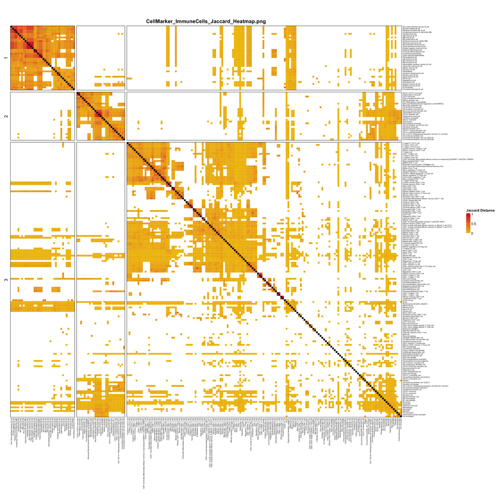

# VAX Sig DB

Os estudos foram filtrados pelo tamanho do conjunto de genes compartilhados (GSSize > 10 ou >50) e com pvalue (<0.25).

Os dados foram anotados no R e depois avaliados manualmente no excel.

```r
#Importar arquivo
VaxSigDB_genesets = VAX_GeneSets_Annotated_26_10_23

# Divida os dados em blocos de informações para cada vacina
vaccines_att <- split(VaxSigDB_genesets$Col2, VaxSigDB_genesets$Col1)

# Combine data
VAX_Genesets <- bind_rows(lapply(vaccines_att, function(x) data.frame(t(x))), .id = "V")

# Name a new index column
colnames(VAX_Genesets) <- paste0("V", seq_len(ncol(VAX_Genesets)))

# Transpose
rownames(VAX_Genesets) <- VAX_Genesets$V1
VAX_Genesets = VAX_Genesets %>%
  t() %>%
  as.data.frame()

#Order columns
VAX_Genesets = VAX_Genesets %>%
  select(STANDARD_NAME, everything()) %>%
  filter(STANDARD_NAME != "STANDARD_NAME")
rownames(VAX_Genesets) = VAX_Genesets$SYSTEMATIC_NAME
VAX_Genesets = VAX_Genesets %>% select(STANDARD_NAME,
                                       DESCRIPTION_BRIEF,
                                       DESCRIPTION_FULL,
                                       PMID,
                                       AUTHORS,
                                       SYSTEMATIC_NAME,
                                       GENE_SYMBOLS,
                                       everything())

#Anotar novas colunas
VAX_Genesets <- VAX_Genesets %>%
  mutate(
    SAMPLE_SOURCE = ifelse(
      grepl("pbmc|peripheral blood mononuclear cell|peripheral blood mononuclear cells", DESCRIPTION_FULL, ignore.case = TRUE) |
      grepl("pbmc|peripheral blood mononuclear cell|peripheral blood mononuclear cells", DESCRIPTION_BRIEF, ignore.case = TRUE),
      "PBMC",
      ifelse(
        grepl("whole blood", DESCRIPTION_FULL, ignore.case = TRUE) |
        grepl("whole blood", DESCRIPTION_BRIEF, ignore.case = TRUE) |
        grepl("_BLOOD", STANDARD_NAME, ignore.case = TRUE)  ,
        "WHOLE BLOOD",
        "OTHER")),
    REGULATION = ifelse(
      grepl("up", DESCRIPTION_BRIEF, ignore.case = TRUE),
      "UP",
      ifelse(
        grepl("down", DESCRIPTION_BRIEF, ignore.case = TRUE),
        "DOWN",
        "UNKNOWN")))

#Reordenar colunas
VAX_Genesets = VAX_Genesets %>% select(SAMPLE_SOURCE, REGULATION, everything())

# Salvar
write.csv(VAX_Genesets, file = "VAXSigDB_Annotated.csv") #Continuar a anotação no Google Sheets

head(VAX_Genesets)

############## Long table with Gene symbols

VAX_Genesets = VAXSigDB_Annotated

# Separar genes por linhas e somar numero de genes
VAX_Genes <- VAX_Genesets %>%
  mutate(GENE = GENE_SYMBOLS) %>%
  separate_rows(GENE, sep = ",") %>%
  select(GENE, everything()) %>%
  group_by(STANDARD_NAME) %>% #Somar e agrupar
  mutate(SetSize = n()) %>%
  relocate(SetSize, .after = GENE_SYMBOLS)

VAX_GeneSets_annotated <- VAX_Genes %>%
  select(-GENE) %>% #Retirar coluna
  distinct() #Retirar linhas repetidas

#Salvar
write.csv(VAX_Genes, file = "VAX_Genes_Annotated_RAW.csv")
write.csv(VAX_GeneSets_annotated, file = "VAX_Genesets_Annotated_RAW.csv")

#Display
head(VAX_GeneSets_annotated)
```

# Descriptive statistics

```r
########## Descriptive statistics
vaccines = VAX_GeneSets_annotated %>%
  group_by(VACCINE, PLATFORM, `TARGET_PATHOGEN_DISEASE`, MICROBE_TYPE) %>%
  summarise(Count = n()) %>%
  arrange(desc(Count))

pathogens = VAX_GeneSets_annotated %>%
  group_by(`TARGET_PATHOGEN_DISEASE`, MICROBE_TYPE) %>%
  summarise(Count = n()) %>%
  arrange(desc(Count))

platforms = VAX_GeneSets_annotated %>%
  group_by(PLATFORM) %>%
  summarise(Count = n()) %>%
  arrange(desc(Count))


#By vaccines -----
vaccine_hist = ggplot(vaccines) +
  aes(x = reorder(VACCINE, Count),
      y = Count,
      fill = `MICROBE_TYPE`) +
  ggtitle("VAX MSigDB - Vaccines, by platform and target") +
  geom_col() +
  geom_text(aes(label = Count), vjust = 0, hjust = 2, size = 3) +
  coord_flip() +
  theme_minimal() +
  labs(fill = "Vaccine target type") +
  theme(plot.title = element_text(face = "bold", colour = "black", size = (20)),
  legend.title = element_text(face = "bold"),
  axis.title = element_text(size = (10), colour = "black"),
  axis.text = element_text(colour = "black", size = (10))) +
  facet_wrap(vars(PLATFORM), scales = "free") +
  scale_fill_manual(values = c('VIRUS'= "#d00000",
                               'BACTERIUM' = "#16E0BD",
                               'PARASITE' = "#118ab2",
                              'MENINGOCOCCUS'   = "#16E0BD",
                             'PNEUMOCOCCUS' = "#44C199",
                             'TUBERCULOSIS' = "#99e2b4",
                             'F TULARENSIS' = "#90e0ef",
                             'LEISHMANIA'   = "#118ab2",
                             'MALARIA' = "#3f37c9",
                             'EBOV' = "#d00000",
                             'HBV'  = "#e85d04",
                             'HBV, HAV' = "#f48c06",
                             'HIV'  = "#a4133c",
                             'HPV'  = "#f27059",
                             'INFLUENZA'    = "#ffa69e",
                             'MEASLES'  = "#c65b7c",
                             'MMR'  = "#f9b5ac",
                             'SMALLPOX' = "#ff8c42",
                             'VEEV' = "#e01e37",
                             'VZV'  = "#ff9b85",
                             'YF'   = "#f38375"))


ggsave(vaccine_hist, file = "VAXSigDB_Vaccines_platforms_pathogens_1.png", width = 25, height = 8)

# By platforms-----

platforms_hist = ggplot(platforms) +
  aes(x = reorder(`PLATFORM`, Count),
      y = Count,
      fill = `PLATFORM`) +
  ggtitle("VAX MSigDB - Vaccine platforms") +
  geom_col() +
  geom_text(aes(label = Count), vjust = 0, hjust = 0, size = 3) +
  coord_flip() +
  theme_minimal() +
  labs(fill = "Platform") +
  theme(plot.title = element_text(face = "bold", colour = "black", size = (20)),
  legend.title = element_text(face = "bold"),
  axis.title = element_text(size = (10), colour = "black"),
  axis.text = element_text(colour = "black", size = (10))) +
  #facet_wrap(vars(PLATFORM), scales = "free") +
  scale_fill_manual(values = c('IN'= "#1e6091",
                               'LA' = "#16E0BD",
                               'VV' = "#34a0a4",
                               'CONJ' = "#76c893",
                               'VLP' = "#b5e48c",
                               'SU' = "#2ec4b6",
                               'LA and IV' = "#cbf3f0",
                               'SUB' = "#00bbf9",
                               'PEP' = "#c0fdff"))

ggsave(platforms_hist, file = "VAXSigDB_Platforms_hist_1.png", width = 10, height = 5)


# By pathogens ----
pathogens_hist = ggplot(pathogens) +
  aes(x = reorder(`TARGET_PATHOGEN_DISEASE`, Count),
      y = Count,
      fill = `MICROBE_TYPE`) +
  ggtitle("VAX MSigDB - Vaccines, by platform and target") +
  geom_col() +
  geom_text(aes(label = Count), vjust = 0, hjust = 0, size = 3) +
  coord_flip() +
  theme_minimal() +
  labs(fill = "Vaccine target type") +
  theme(plot.title = element_text(face = "bold", colour = "black", size = (20)),
  legend.title = element_text(face = "bold"),
  axis.title = element_text(size = (10), colour = "black"),
  axis.text = element_text(colour = "black", size = (10))) +
  #facet_wrap(vars(PLATFORM), scales = "free") +
  scale_fill_manual(values = c('VIRUS'= "#d00000",
                               'BACTERIUM' = "#16E0BD",
                               'PARASITE' = "#118ab2",
                              'MENINGOCOCCUS'   = "#16E0BD",
                             'PNEUMOCOCCUS' = "#44C199",
                             'TUBERCULOSIS' = "#99e2b4",
                             'F TULARENSIS' = "#90e0ef",
                             'LEISHMANIA'   = "#118ab2",
                             'MALARIA' = "#3f37c9",
                             'EBOV' = "#d00000",
                             'HBV'  = "#e85d04",
                             'HBV, HAV' = "#f48c06",
                             'HIV'  = "#a4133c",
                             'HPV'  = "#f27059",
                             'INFLUENZA'    = "#ffa69e",
                             'MEASLES'  = "#c65b7c",
                             'MMR'  = "#f9b5ac",
                             'SMALLPOX' = "#ff8c42",
                             'VEEV' = "#e01e37",
                             'VZV'  = "#ff9b85",
                             'YF'   = "#f38375"))

ggsave(pathogens_hist, file = "VAXSigDB_Pathogens_hist_1.png", width = 10, height = 5)
```